# Confidence Intervals

Albert Y. Kim

Mon Nov 21, 2016

Let’s revisit the OkCupid profile data. Run the following in your console:

```r
library(mosaic)
library(dplyr)
library(ggplot2)

library(okcupiddata)
data(profiles)

# Added line: let's remove all users (i.e. rows) who did not list a height. is.na() returns
# TRUE if missing, so we want those that are NOT missing.
profiles <- profiles %>%
  filter(!is.na(height))
```

Then run the following:

```r
n <- 5
samples <- do(10000) *
  mean(resample(profiles$height, size=n, replace=TRUE))
samples <- samples %>%
  as_data_frame()
ggplot(samples, aes(x=mean)) +
  geom_histogram(binwidth = 1) +
  xlim(c(40,90))
```

## Learning Checks

1. Discuss with your seatmates what the following code does.
2. Try varying `n`. What does this correspond to doing?
3. How does the histogram change?

#### LC1

This code

- Samples `n=5` OkCupid users with replacement from the **population** of OkCupid users
- Computes the sample mean height $\overline{x} = \frac{1}{n}\sum_{i=1}^{n}x_i$, where $x_i$ is the height of the $i$th sampled user out of $n$.
- Does this many, many, many times i.e. 10000 times
- Plots the **distribution** of these 10000 values of $\overline{x}$ via a histogram

#### LC2

Varying `n` corresponds to sampling a different amount of people. Here are the histogram of sample means when

- `n=5`
- `n=50`

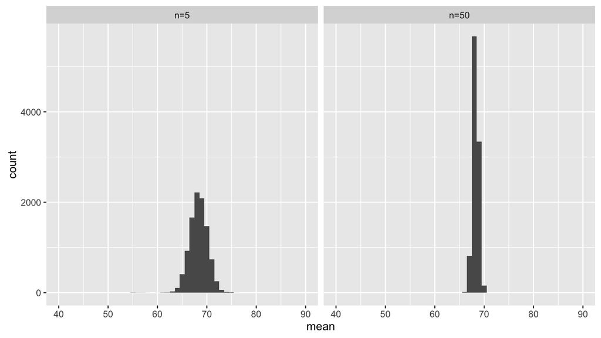

## Extra

#### Point Estimate of True Population Mean

Recall that in both cases, the sample mean $\overline{x}$ is a **point estimate** of the **true population mean $\mu$**, i.e. the true mean height of all 60K OkCupid users. i.e. $\mu$ = 68.3 inches (or about 5’8’’). Let’s plot this value in red:

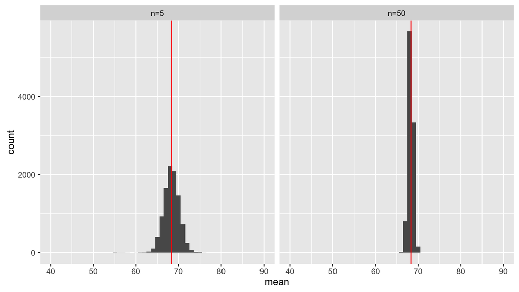

We see that using `n=50`, our sample means $\overline{x}$ i.e. our point estimates of $\mu$ are more often closer to the true population mean in red. **We are more often closer to the true value**. This is why sample size matters!

#### Confidence Interval

Let’s look at the middle 95% of values for `n=5`. It is [65.0, 71.6]. i.e.

- 2.5% of values are to the left of the left dashed line
- 95% of values are between the two dashed lines
- 2.5% of values are to the right of the right dashed line

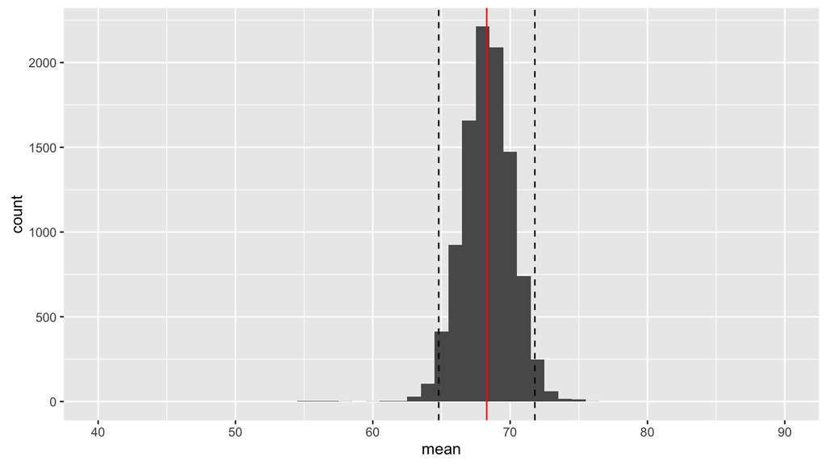

Let’s look at the middle 95% of values for `n=50`. It is [67.18, 69.40]:

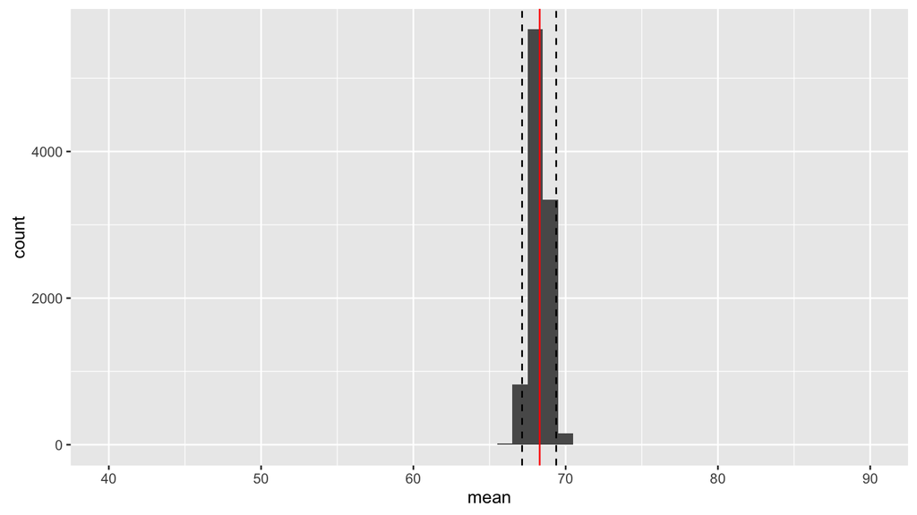